# Scooby Doo

Connor Hudziak

2/4/2022

## Introduction

The Scooby data set consists of 75 columns of unique information from every Scooby Doo episode. The topic that I wanted to focus further on is the relationship between the network and arrest rates along with their imdb rating. I wanted to see if viewers favored a certain network over the others. As well as look and come to the conclusion that arrest rates could’ve related to a more exciting episode that produces a higher imdb rating.

## Computing Arrest Rates

In this section I am computing the average percentage of an arrest occurring by network. I filtered out the data by network and then took the percentage of TRUE recordings in the arrest column.

```r
Network_names <- c("CBS", "ABC", "Cartoon Network", "The WB", "Boomerang")

arrest_rates <- c(.857, .829, .890, .775, .877)

arrest <- data.frame(Networks = Network_names, Arrest_Rates = arrest_rates)
```

## Arrest Rates by Network

This depicts the arrest rate of criminals by network of Scooby Doo. I found it interesting that majority of the networks produced a 75% or higher arrest rate. As you can see I have omitted the the CW network as the data provided did not have accurate readings of arrest rates. I also omitted the Warner Home Video network as they mostly aired Scooby Doo specials which did not accurately give a quality result for the overall data.

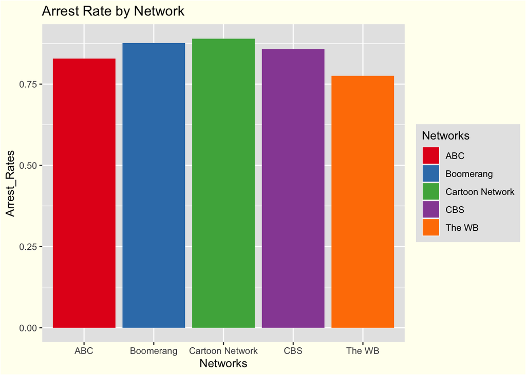

```r
ggplot(arrest, aes(x = Networks, y = Arrest_Rates, fill = Networks)) +
  geom_col()+
  scale_fill_brewer(palette = "Set1")+
  labs(title = "Arrest Rate by Network")+
  theme(plot.background = element_rect(fill = "ivory"),
        panel.background = element_rect(fill = "grey90"),
        legend.background = element_rect(fill = "grey90"))
```

## Computing IMDB Means

In this section I am calculating the mean of IMDB ratings according to their network. I filtered out the Networks and found the mean of their IMDB ratings for Scooby Doo episodes.

```r
## Graph code
Network_names <- c("CBS", "ABC", "Cartoon Network", "The WB", "The CW",
                   "Warner Home Video", "Boomerang")

imdb_means <- c(7.90, 7.17, 8.05, 7.43, 5.60, 6.90, 7.57)

imdb <- data.frame(Networks = Network_names, IMDB_Ratings = imdb_means)
```

## Average IMDB by Network

Below is the average IMDB ratings by Network in the Scooby Doo series. I found it interesting that Cartoon Network had the highest rating out of all as well as having the highest arrest rate compared to other networks. The lowest average rating belongs to the CW network and looking at the graph it is well below the others.

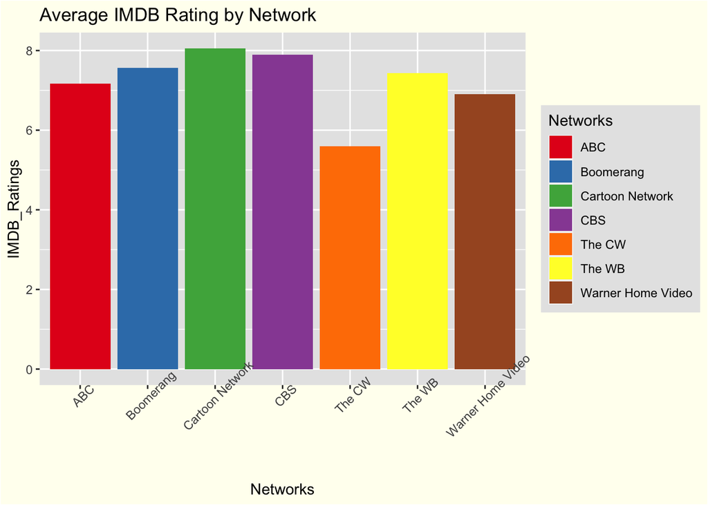

```r
ggplot(imdb, aes(x = Networks, y = IMDB_Ratings, fill = Networks)) +
  geom_col()+
  scale_fill_brewer(palette = "Set1")+
  labs(title = "Average IMDB Rating by Network")+
  theme(axis.text.x = element_text(angle = 45),
        plot.background = element_rect(fill = "ivory"),
        panel.background = element_rect(fill = "grey90"),
        legend.background = element_rect(fill = "grey90"))
```

## Conclusion

Looking at the visualizations, Cartoon Network is the highest in both categories of arrest rates and IMDB ratings. Cartoon Network had an average arrest rate of 89% and the average IMDB rating of 8.05. I find it interesting that there could be a link between higher arrest rate and the higher IMDB rating. As the list goes down in both graphs, the networks closely match up similarly to this theory. Looking at the the CW network, I would have wondered what the actual rate of arrest in the network was. I believe that it could be lower given the lower IMDB rating but unfortunately the data was not collected and therefore could not be used.

Sources:

1. https://www.kaggle.com/williamschooleman/scoobydoo-complete
2. https://scoobydoo.fandom.com/wiki/Scoobypedia
3. https://www.youtube.com/c/EquitableEquations